## Synopsis

This report analyzes the NOAA storm data and finds out that tornado, heat and floods are the three most harmful events to population health (measured by number of fatalities and injuries). With respect to economic damages, floods have done the biggest damage since 1950 to 2011.

## Reading and Preprocessing the Data

We first start by reading the data.

```r
# Reading the dataset may take a bit long.
Sys.setlocale('LC_ALL', 'C')
```

```
## [1] "C"
```

```r
data = read.csv("repdata-data-StormData.csv", header = TRUE)
```

Then we take a look at the data and decide what variables we are going to use for this analysis.

```r
names(data)
```

```
##  [1] "STATE__"    "BGN_DATE"   "BGN_TIME"   "TIME_ZONE"  "COUNTY"
##  [6] "COUNTYNAME" "STATE"      "EVTYPE"     "BGN_RANGE"  "BGN_AZI"
## [11] "BGN_LOCATI" "END_DATE"   "END_TIME"   "COUNTY_END" "COUNTYENDN"
## [16] "END_RANGE"  "END_AZI"    "END_LOCATI" "LENGTH"     "WIDTH"
## [21] "F"          "MAG"        "FATALITIES" "INJURIES"   "PROPDMG"
## [26] "PROPDMGEXP" "CROPDMG"    "CROPDMGEXP" "WFO"        "STATEOFFIC"
## [31] "ZONENAMES"  "LATITUDE"   "LONGITUDE"  "LATITUDE_E" "LONGITUDE_"
## [36] "REMARKS"    "REFNUM"
```

Questions we need to answer within this analysis are:

1. Across the United States, which types of events (as indicated in the **EVTYPE** variable) are most harmful with respect to population health?
2. Across the United States, which types of events have the greatest economic consequences?

To answer these questions, we choose the following variables to do the analysis.

- EVTYPE: Demonstrates the type of the storm;
- FATALITIES: Number of deaths caused by the storm event;
- INJURIES: Number of injuries caused by the storm event;
- PROPDMG: Measures the damage of properties;
- PROPDMGEXP: An multiplier for PROPDMG, where where Hundred (H), Thousand (K), Million (M), Billion (B) and numbers stand for the power of ten, i.e., 5 means that the multiplier is 10^5
- CROPDMG: Measures the damage of crops;
- CROPDMGEXP: An multiplier for CROPDMG, where where Hundred (H), Thousand (K), Million (M), Billion (B) and numbers stand for the power of ten, i.e., 5 means that the multiplier is 10^5

Now save all these variables within a new object named *newdata*.

```r
newdata <- data.frame(EVTYPE=data$EVTYPE, FATALITIES=data$FATALITIES, INJURIES=data$INJURIES, PROPDMG=data$PROPDMG, PROPDMGEXP=data$PROPDMGEXP, CROPDMG=data$CROPDMG, CROPDMGEXP=data$CROPDMGEXP)
```

First we look into the **EVTYPE** variable and find that there are many different and inconsistent descriptions about the event type. According to the information from the National Weather Service Storm Data Documentation, Page 6 (https://d396qusza40orc.cloudfront.net/repdata%2Fpeer2_doc%2Fpd01016005curr.pdf), we categorize all events using the event table and store it in a csv file, the content of which is shown as below. (Note the column named “keyword” is used to better categorize the event type.)

```r
eventtype <- read.csv("EventType.csv", header = TRUE)
#One can reproduce this file simply by copying the content below
eventtype
```

```
##                       Event Designator                  Keyword
## 1     Astronomical Low Tide          Z    Astronomical Low Tide
## 2                 Avalanche          Z                Avalanche
## 3                  Blizzard          Z                 Blizzard
## 4             Coastal Flood          Z            Coastal Flood
## 5           Cold/Wind Chill          Z                     Cold
## 6               Debris Flow          C              Debris Flow
## 7                 Dense Fog          Z                Dense Fog
## 8               Dense Smoke          Z              Dense Smoke
## 9                   Drought          Z                  Drought
## 10               Dust Devil          C               Dust Devil
## 11               Dust Storm          Z               Dust Storm
## 12           Excessive Heat          Z           Excessive Heat
## 13  Extreme Cold/Wind Chill          Z             Extreme Cold
## 14              Flash Flood          C              Flash Flood
```

[output cut: 34 more lines]

Then using the event table, we can categorize the **EVTYPE**. If one observation, if the value contains any keyword in the event table, we will count that observation as in that category. If the value doesn’t contain any keyword from the table, we just leave it there as it is. Using the *grep()* function we created a new column, called NEWEVENT, in the new data set. Codes are shown as below.

```r
i <- 1
w <- as.character(newdata$EVTYPE)
for(cat in eventtype$Keyword){
  index <- grep(toupper(cat), newdata$EVTYPE, ignore.case = TRUE)
  w[index] <- as.character(eventtype$Event[i])
  i <- i + 1
}
newdata <- data.frame(NEWEVENT = w, newdata)
```

Thus we now have a more consistent column for the event type variable. Next, we need to fixed some missing or inconsistent data of other variables. Codes are shown as below.

```r
# Replace all missing values with 0
newdata$FATALITIES[(newdata$FATALITIES == "")] <- 0
newdata$INJURIES[(newdata$INJURIES == "")] <- 0
newdata$PROPDMG[(newdata$PROPDMG == "")] <- 0
newdata$CROPDMG[(newdata$CROPDMG == "")] <- 0

# Only use numbers for variables of PROPDMGEXP and CROPDMGEXP
newdata$PROPDMGEXP <- as.character(newdata$PROPDMGEXP)
newdata$CROPDMGEXP <- as.character(newdata$CROPDMGEXP)

newdata$PROPDMGEXP[(newdata$PROPDMGEXP == "+") | (newdata$PROPDMGEXP == "-") | (newdata$PROPDMGEXP == "?") | (newdata$PROPDMGEXP == "")] <- 0
newdata$PROPDMGEXP[(newdata$PROPDMGEXP == "h") | (newdata$PROPDMGEXP == "H")] <- 2
newdata$PROPDMGEXP[(newdata$PROPDMGEXP == "k") | (newdata$PROPDMGEXP == "K")] <- 3
newdata$PROPDMGEXP[(newdata$PROPDMGEXP == "m") | (newdata$PROPDMGEXP == "M")] <- 6
newdata$PROPDMGEXP[(newdata$PROPDMGEXP == "B")] <- 9

newdata$CROPDMGEXP[(newdata$CROPDMGEXP == "+") | (newdata$CROPDMGEXP == "-") | (newdata$CROPDMGEXP == "?") | (newdata$CROPDMGEXP == "")] <- 0
newdata$CROPDMGEXP[(newdata$CROPDMGEXP == "h") | (newdata$CROPDMGEXP == "H")] <- 2
newdata$CROPDMGEXP[(newdata$CROPDMGEXP == "k") | (newdata$CROPDMGEXP == "K")] <- 3
newdata$CROPDMGEXP[(newdata$CROPDMGEXP == "m") | (newdata$CROPDMGEXP == "M")] <- 6
newdata$CROPDMGEXP[(newdata$CROPDMGEXP == "B")] <- 9

newdata$PROPDMGEXP <- as.numeric(newdata$PROPDMGEXP)
newdata$CROPDMGEXP <- as.numeric(newdata$CROPDMGEXP)
```

Now the data set, **newdata**, is ready for doing analysis.

## Analysis

Using the new data set we just created, in order to evaluate the damage to population health and economics, we need to calculate the total damage for each event.

```r
econdamage <- newdata$PROPDMG * (10 ^ newdata$PROPDMGEXP) + newdata$CROPDMG * (10 ^ newdata$CROPDMGEXP)
newdata <- data.frame(newdata, ECONDAMAGE = econdamage)

# Calculate the total damage of each type of events.
totalecondamage <- sapply(split(newdata$ECONDAMAGE, newdata$NEWEVENT), sum)
totalecondamage <- totalecondamage[order(totalecondamage, decreasing=TRUE)]
totalfataldamage <- sapply(split(newdata$FATALITIES, newdata$NEWEVENT), sum)
totalfataldamage <- totalfataldamage[order(totalfataldamage, decreasing=TRUE)]
totalinjuredamage <- sapply(split(newdata$INJURIES, newdata$NEWEVENT), sum)
totalinjuredamage <- totalinjuredamage[order(totalinjuredamage, decreasing=TRUE)]
```

## Results

In this section we use the package ggplot2 to show the results. Codes are shown as below.

### Top 5 Fatalities Events

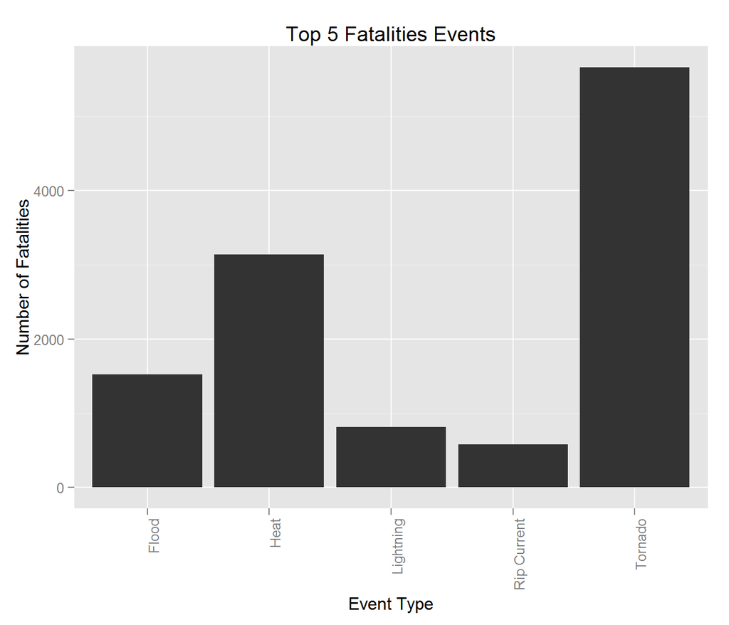

```r
library(ggplot2)

gdata <- data.frame(number = head(totalfataldamage, n=5), name = names(head(totalfataldamage, n=5)))
g <- ggplot(data = gdata, aes(x = name, y = number)) + geom_bar(stat = "identity") + theme(axis.text.x = element_text(angle = 90, hjust = 1)) + xlab("Event Type") + ylab("Number of Fatalities") + ggtitle("Top 5 Fatalities Events")
print(g)
```

As we can see, Tornado has the largest number of fatalities.

### Top 5 Injuries Events

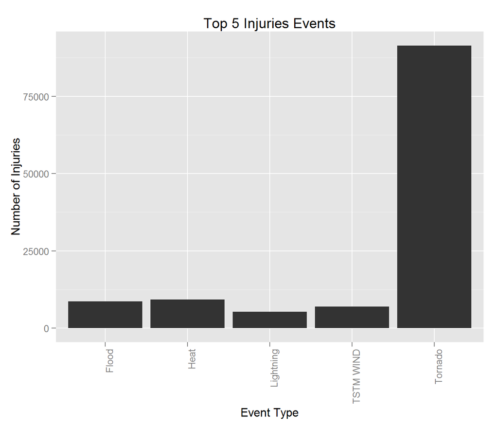

```r
gdata <- data.frame(number = head(totalinjuredamage, n=5), name = names(head(totalinjuredamage, n=5)))
g <- ggplot(data = gdata, aes(x = name, y = number)) + geom_bar(stat = "identity") + theme(axis.text.x = element_text(angle = 90, hjust = 1)) + xlab("Event Type") + ylab("Number of Injuries") + ggtitle("Top 5 Injuries Events")
print(g)
```

Still, Tornado has the largest number of injuries.

### Top 5 Economic Damage Events

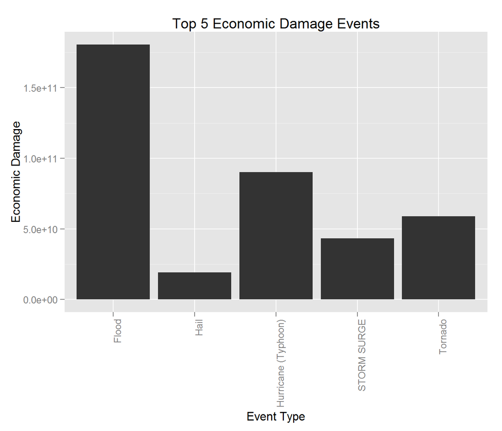

```r
gdata <- data.frame(number = head(totalecondamage, n=5), name = names(head(totalecondamage, n=5)))
g <- ggplot(data = gdata, aes(x = name, y = number)) + geom_bar(stat = "identity") + theme(axis.text.x = element_text(angle = 90, hjust = 1)) + xlab("Event Type") + ylab("Economic Damage") + ggtitle("Top 5 Economic Damage Events")
print(g)
```

In total, Flood has the biggest damage to the economics.